# Data Analytics - Shiny App

# Shiny App - Pitch

Let us present a little app that gathers the various aspects of Data Analysis with R we’ve tackle during the Data analytics course.

- Data loading
- Data cleaning
- Features selection
- Features analysis with graphics

**Context** : “A real estate investor is looking forward to using this data in order to take a decision regarding the best option he has in real estate to generate profit on Airbnb from his investment.”

**Data** : Airbnb Records from http://insideairbnb.com

**tools** : [dplyr](https://dplyr.tidyverse.org), [ggplot2](https://ggplot2.tidyverse.org/reference/ggplot.html), [leaflet](https://leafletjs.com), [shiny](https://shiny.rstudio.com), slidy2

```
                      Pierre-Mathieu Barras - Marius Sorrin - Camille Marini
```

# Overview - Subject

- We have to take care to select the best possible features and graphics to make effective decision making : **availability, price and revenue**
- As real estate investors, we selected some indicators to be able to compare the cities with each other (and their neigborhoods)
- For the sake of simplicity we have only selected Western European cities for the moment.

# Preprocessing : get data and prepare it

A part of the script were given but we added some functions

[figure not shown]

# App architecture - server and ui

- The UI part organizes the general layout, binds the inputs (**city, features to compare, graphics and metrics selection**) and renders the outputs (**plots, specific values**)
- The server part **catches the UI inputs** to do the computations and **sends the results back to the UI as outputs**. Other underlying functions could be implemented (Zoom function for exemple)
- The model of analysis is splited in two parts:
  - A quick analysis to differentiate between cities (*which city to invest in ?*)
  - A more detailed analysis of a specific city (*what kind of investment in that city ?*)

# Graphical analysis - quick view and global comparaisons

A quick analysis to differentiate between cities (*which city to invest in ?*)

- select one or more city
- select a metric (availability, price, revenue)
- select an aggregation type
- overlay one other critera

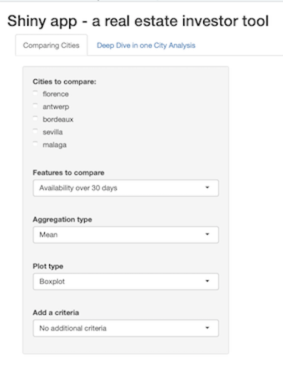

# Graphical analysis - Quick view and global comparaisons

- The investor can use 3 differents graphics : **Boxplot, Histogram and density function**

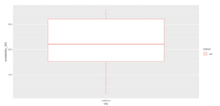

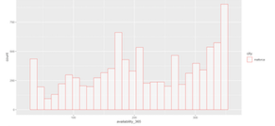

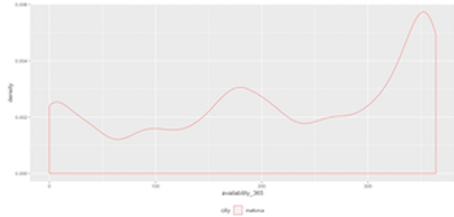

- To easy the comparaison, it’s possible to **overlay the graphics of dfferent cities** an even **add dimensions**

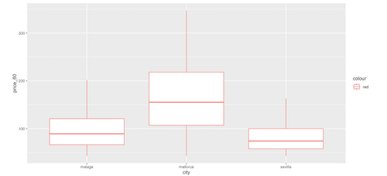

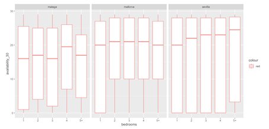

- When there are too many features, the graphics quickly become unreadable, so it is possible to **zoom in and out**

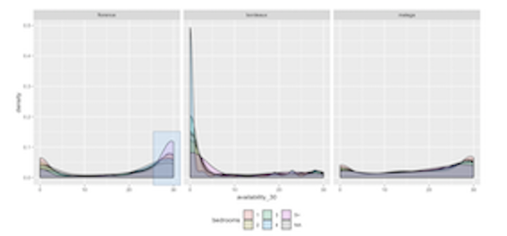

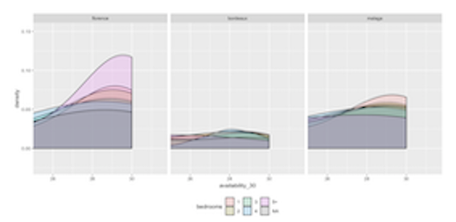

# Graphical analysis - Dive into a specific city

A more detailed analysis of a specific city (*what kind of investment in that city ?*)

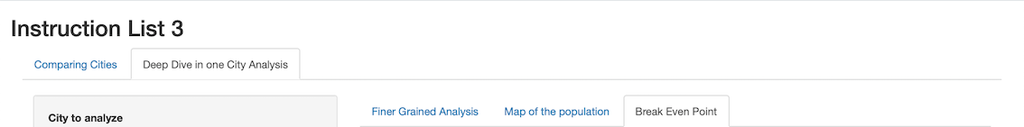

First you can compare any metric over 10 neigborhoods, the room types and the numbers of bedrooms at the same time.

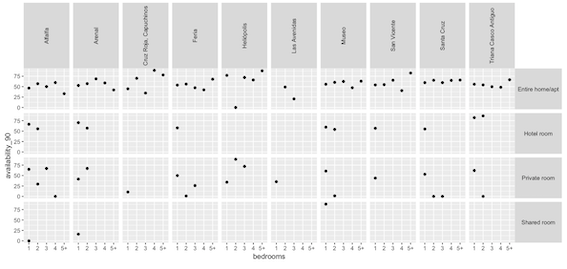

You can also plot a map to better understand the distribution within cities

[interactive chart not shown]

# Bonus - Break Even Point analysis, Zoom function

- The period in years when the investement starts to generates benefits for the investor.
- Approach based on fixed costs and variable costs.
- Estimation of more profitable cities.

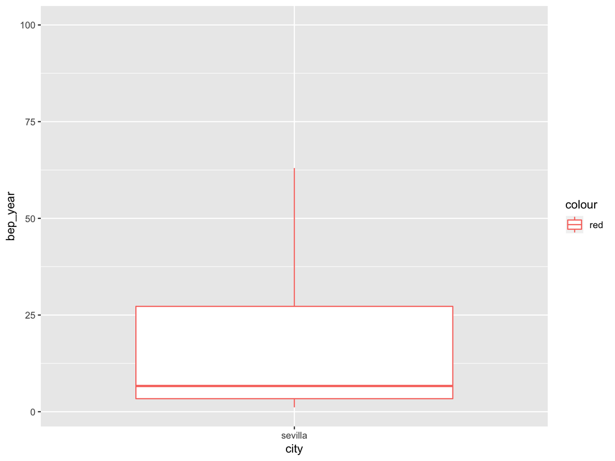

# Conclusion

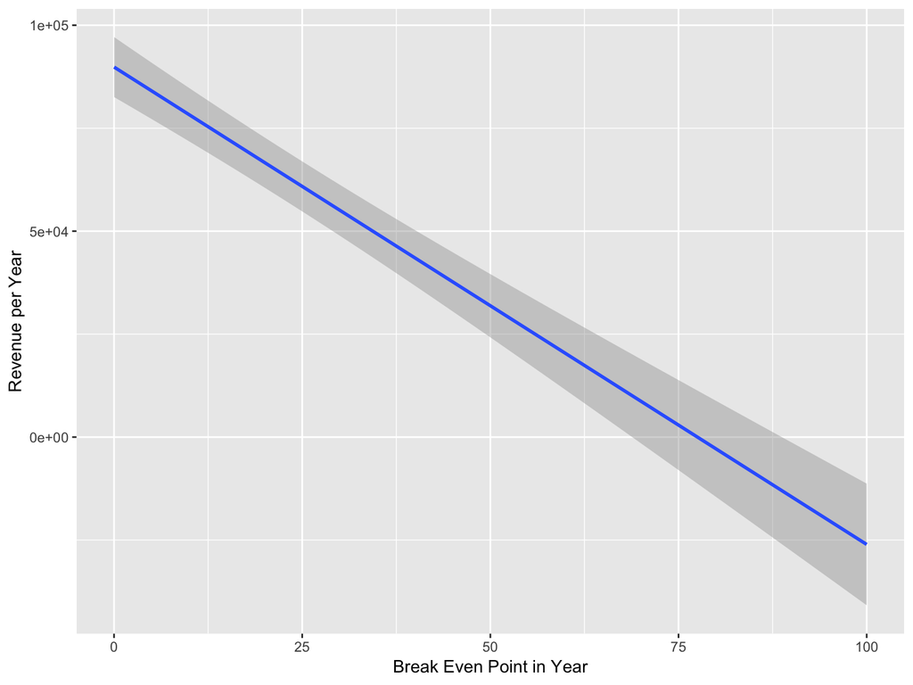